# Biostatistik, Teilprüfung (Einheiten 5-8):

Adam Clark

2023-19-12, Nacholungs Gruppe 2

**Anleitungen:** Bitte die folgenden Fragen beantworten, und die Antworten im *Biostatistik_K5-8_Teilprüfung_GRUPPE_NAME.docx* Dokument einfügen (wo GRUPPE and NAME dein Name und deine Gruppe andeuten). Das Dokument muss bis Ende unserer Abhaltung zum Moodle hochgeladen werden. Ihr dürft Notizen und Kursfolien während der Prüfung verwenden – aber, Zusammenarbeit ist nicht erlaubt. Bitte alle gelbmarkierte Felder (inklusiv Name!!) ausfüllen. Die Prüfung entspricht insgesamt 50 Punkte, über 5 Teilen.

#### **Teil 1:** *Scatterplot Muster Erkennen (6 Punkte Insgesamt)*

*Frage 1.1:* Welche Abbildung hat der höchster R2-wert? (1 Punkt)

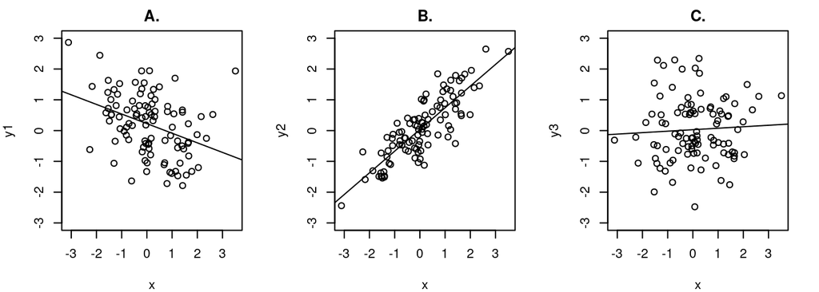

*Frage 1.2:* Welche Abbildung hat der höchster R2-wert? (1 Punkt)

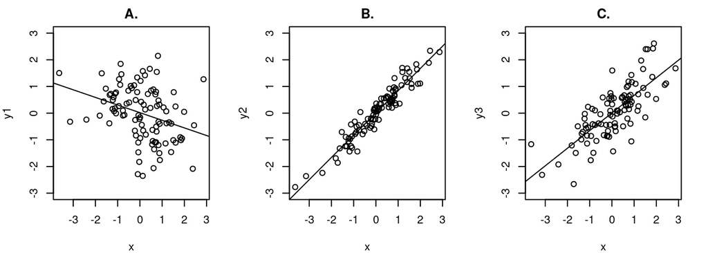

*Frage 1.3:* Welche Steigung zeigt die größte Effektsgröße (egal ob positiv oder negativ)? (1 Punkt)

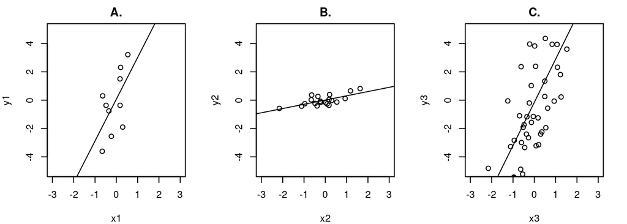

*Frage 1.4:* Welche Steigung zeigt die größte Effektsgröße (egal ob positiv oder negativ)? (1 Punkt)

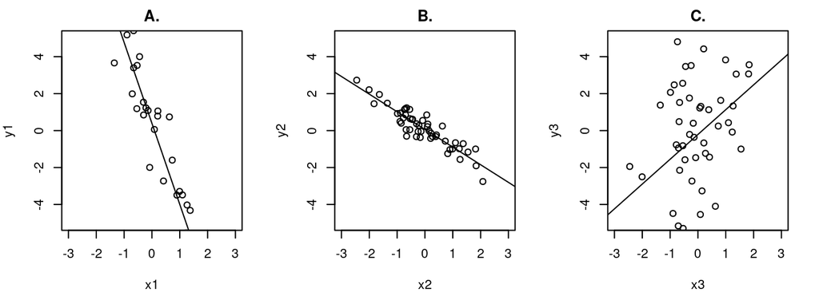

*Frage 1.5:* Zu welcher Steigung passt der kleinster p-Wert? (1 Punkt)

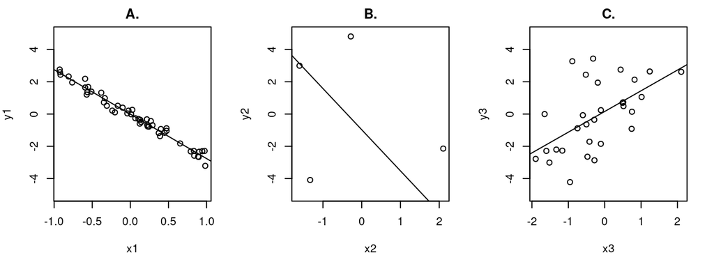

*Frage 1.6:* Zu welcher Steigung passt der kleinster p-Wert? (1 Punkt)

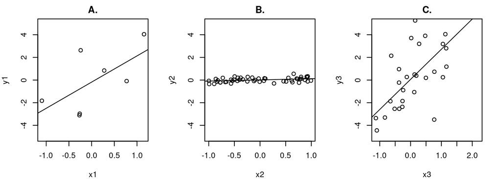

*Frage 2.1:* Welche Verteilung stellt der kleinster p-Wert da? (1 Punkt)

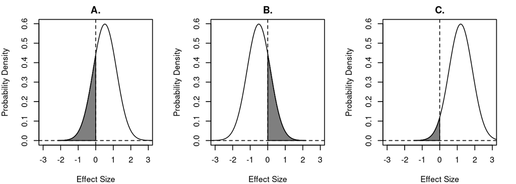

*Frage 2.2:* Welche Verteilung stellt der kleinster p-Wert da? (1 Punkt)

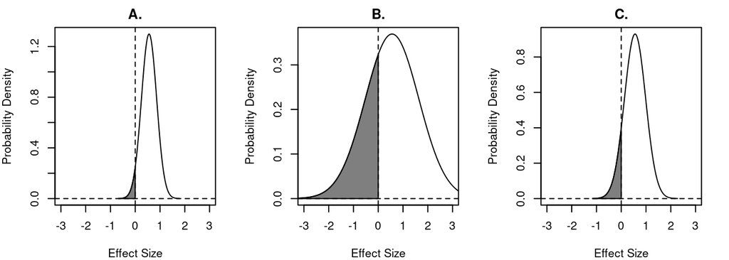

*Frage 2.3:* Welche Verteilung stellt der kleinster p-Wert da? (1 Punkt)

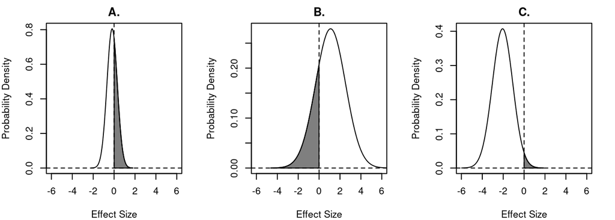

*Frage 2.4:* Welche Verteilung stellt die größte Effektsgröße da (egal ob positiv oder negativ)? (1 Punkt)

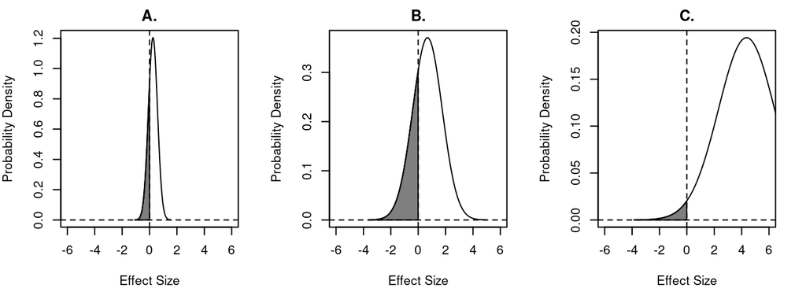

*Frage 2.5:* Welche Verteilung stellt die größte Effektsgröße da (egal ob positiv oder negativ)? (1 Punkt)

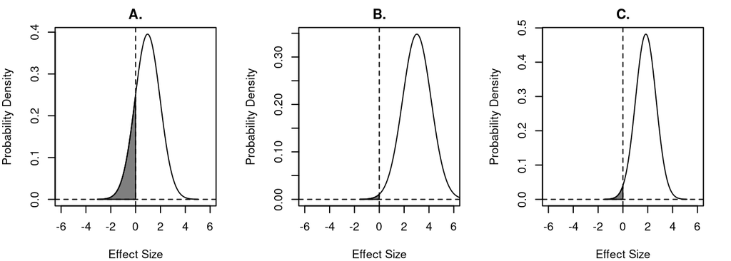

*Frage 2.6:* Welche Verteilung stellt die größte Effektsgröße da (egal ob positiv oder negativ)? (1 Punkt)

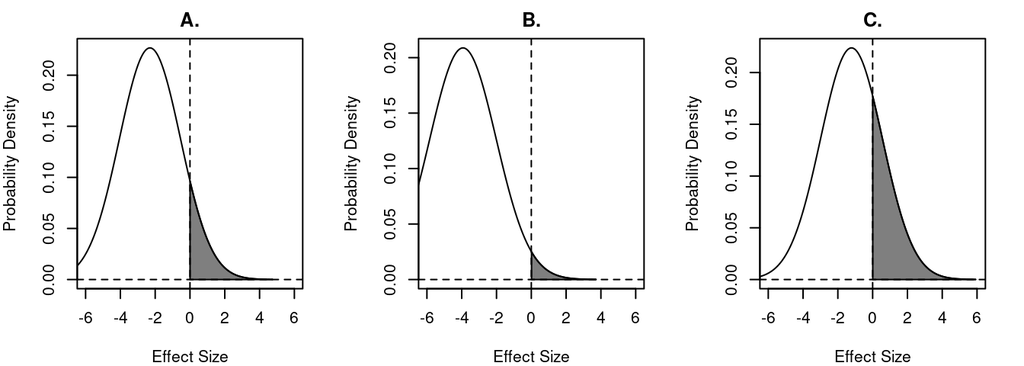

#### **Teil 3:** *Univariate Regression (12 Punkte Insgesamt)*

*Frage 3.1:* Was ist der R2 für diese Regression? Was ist die Steigung? Was ist der p-Wert für die Steigung? Zwei Nachkommastellen reichen. (3 Punkte)

```
##
## Call:
## lm(formula = y ~ x)
##
## Residuals:
##      Min       1Q   Median       3Q      Max
## -18.5078  -4.1063   0.1108   4.4498  13.3450
##
## Coefficients:
##             Estimate Std. Error t value Pr(>|t|)
## (Intercept)   1.0779     1.2528   0.860  0.39165
## x            -0.9234     0.2896  -3.188  0.00192 **
## ---
## Signif. codes:  0 '***' 0.001 '**' 0.01 '*' 0.05 '.' 0.1 ' ' 1
##
## Residual standard error: 6.087 on 98 degrees of freedom
## Multiple R-squared:  0.09396,    Adjusted R-squared:  0.08472
## F-statistic: 10.16 on 1 and 98 DF,  p-value: 0.001923
```

*Frage 3.2:* Für die Daten aus Frage 3.1, was ist der Intercept? Was ist der p-Wert für den Intercept? Zwei Nachkommastellen reichen. (2 Punkte)

*Frage 3.3:* Für die folgende Abbildung, was ist (ungefähr) der Intercept? Was ist (ungefähr) die Steigung? Du musst keine Nachkommastellen angeben. (2 Punkte)

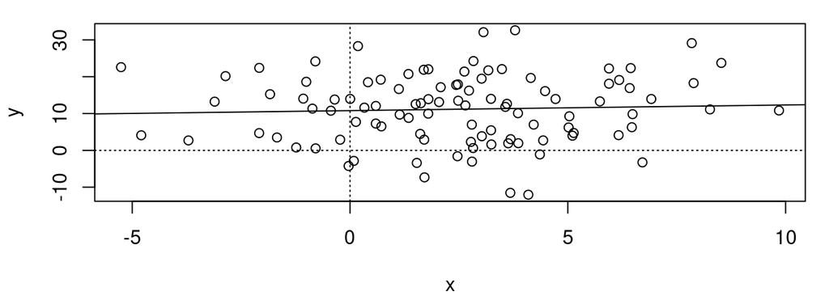

*Frage 3.4:* Was ist der R2 für diese Regression? Was ist die Steigung? Was ist der p-Wert für die Steigung? Zwei Nachkommastellen reichen. (3 Punkte)

```
##
## Call:
## lm(formula = y ~ x)
##
## Residuals:
##     Min      1Q  Median      3Q     Max
## -20.779  -5.674  -0.602   6.710  18.879
##
## Coefficients:
##             Estimate Std. Error t value Pr(>|t|)
## (Intercept)   1.0728     1.0227   1.049    0.297
## x             1.8142     0.3257   5.570 2.23e-07 ***
## ---
## Signif. codes:  0 '***' 0.001 '**' 0.01 '*' 0.05 '.' 0.1 ' ' 1
##
## Residual standard error: 8.545 on 98 degrees of freedom
## Multiple R-squared:  0.2405, Adjusted R-squared:  0.2327
## F-statistic: 31.03 on 1 and 98 DF,  p-value: 2.233e-07
```

*Frage 3.5:* Für die Daten aus Frage 3.4, was ist der Intercept? Was ist der p-Wert für den Intercept? Zwei Nachkommastellen reichen. (2 Punkte)

#### **Teil 4:** *Multivariate Regression (14 Punkte Insgesamt)*

*Frage 4.1:* Für die folgende multivariate Regression, haben wir drei Prädiktoren: “a”, “b”, und “c”. Für jeder Prädiktor, was ist die Effektgröße, und was ist der p-Wert? Zwei Nachkommastellen reichen. (6 Punkte)

```
##
## Call:
## lm(formula = y ~ a + b + c)
##
## Residuals:
##     Min      1Q  Median      3Q     Max
## -3.7820 -1.5180 -0.4384  1.8056  3.6300
##
## Coefficients:
##             Estimate Std. Error t value Pr(>|t|)
## (Intercept)  -1.7689     1.7214  -1.028   0.3194
## a            -4.9070     0.1978 -24.809 3.37e-14 ***
## b            -0.7338     0.3583  -2.048   0.0573 .
## ctreatment    5.2484     1.0193   5.149 9.70e-05 ***
## ---
## Signif. codes:  0 '***' 0.001 '**' 0.01 '*' 0.05 '.' 0.1 ' ' 1
##
## Residual standard error: 2.255 on 16 degrees of freedom
## Multiple R-squared:  0.9767, Adjusted R-squared:  0.9723
## F-statistic: 223.7 on 3 and 16 DF,  p-value: 2.854e-13
```

*Frage 4.2:* Für den Regression in Frage 4.1, welche Art von Variablen sind “a”, “b”, und “c” (kontinuierliche oder kategorische)? (3 Punkte)

*Frage 4.3:* Die unten angezeigte Regression ist identisch zu die in 4.1, aber mit einem zusätzlichen Prädiktor “d”. Trägt dieser Prädiktor zu einer Erhöhung des Informationswerts der Regression bei? Mit welchem Wert aus den zwei Tabellen in 4.1 und 4.3 können wir den Beitrag von “d” testen? (2 Punkte)

```
##
## Call:
## lm(formula = y ~ a + b + c + d)
##
## Residuals:
##     Min      1Q  Median      3Q     Max
## -3.7487 -1.4688 -0.4293  1.6861  3.6302
##
## Coefficients:
##             Estimate Std. Error t value Pr(>|t|)
## (Intercept) -2.12591    3.01823  -0.704 0.492003
## a           -4.90476    0.20471 -23.959 2.27e-13 ***
## b           -0.74360    0.37571  -1.979 0.066456 .
## ctreatment   5.26696    1.05956   4.971 0.000168 ***
## d            0.09467    0.64695   0.146 0.885605
## ---
## Signif. codes:  0 '***' 0.001 '**' 0.01 '*' 0.05 '.' 0.1 ' ' 1
##
## Residual standard error: 2.327 on 15 degrees of freedom
## Multiple R-squared:  0.9767, Adjusted R-squared:  0.9705
## F-statistic: 157.5 on 4 and 15 DF,  p-value: 4.664e-12
```

*Frage 4.4:* Die folgende Abbildung zeigt eine Regression von “y” gegen kontinuierlicher Prädiktor “x” und kategorischer Prädiktor “z” (mit kategoriale Werte “rot” und “blau”). Ist dieses Verhältnis ohne Interaktion (y~x+z) oder mit Interkation (y~x*z) dargestellt? (1 Punkt)

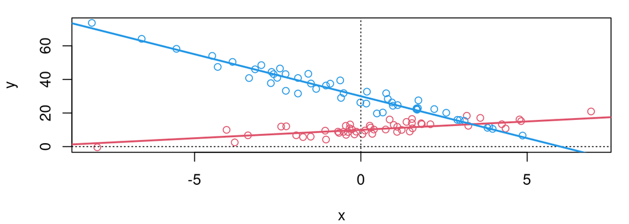

*Frage 4.5:* Gleiche Frage als in 4.4, aber für die folgende Abbildiung (1 Punkt)

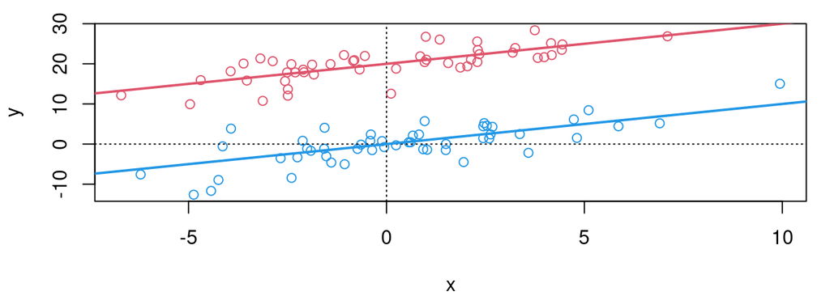

Frage 4.6: Für die folgende AIC Tabelle, welcher Model ist nach AIC Wert als „bestes“ bezeichnet? (1 Punkt)

```
##      df      AIC
## mod1  5 310.7164
## mod2  4 404.8819
## mod3  3 534.2021
## mod4  3 450.1925
## mod5  2 538.4487
```

#### **Teil 5:** *Model Selektion (12 Punkte Insgesamt)*

Beantworte die folgenden Fragen zum Datensatz in “test_data_GRUPPE.csv” (wo “GRUPPE” diene Gruppennummer andeutet) auf der Moodle Seite. Ziel von dieser Aufgabe ist, ein Model zu finden, dass Variabilität in der “biomass” Variable zu erklären, durch eine Multivariate Regression mit bis zu zwei möglichen Prädiktoren: “planted_richness”, und “standort”. Eine Abbildung von den Relationen in diese Daten ist unten beigefügt:

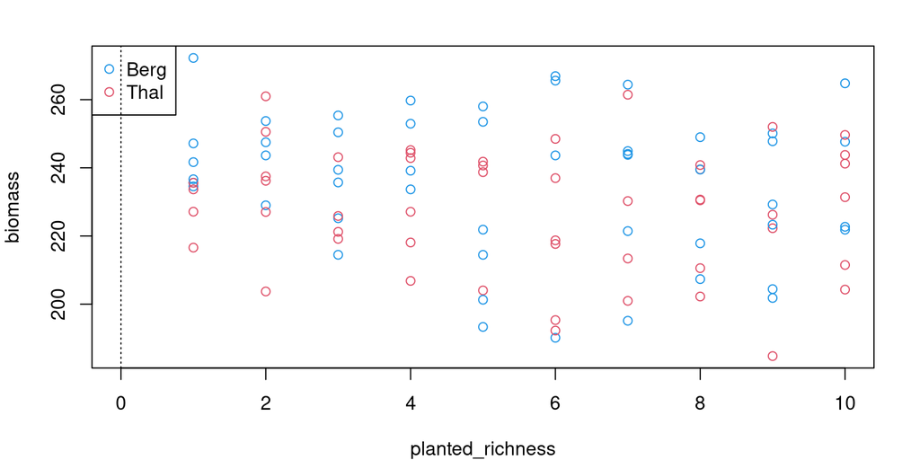

*Frage 5.1:* Lade die Daten in R ein, und erstelle eine Regression mit den folgenden Relationen:

biomass ~ planted_richness*standort

Was ist der R2 Wert, und der „Adjusted“ R2 Wert, für diese Regression? (1 Punkt)

*Frage 5.2:* Fitte jetzt drei unterschiedliche vereinfachte Regressionen mit diese Daten (z.B. mit oder ohne Interaktionen, oder als Univariate Regressionen). Alle drei Regressionen müssen „nested“ sein (d.h., sie sollten sich durch nur ein Prädiktor unterscheiden). Schreibe die Relationen für deine ausgewählte Regressionen unten auf. (3 Punkte)

*Frage 5.3:* Verwende jetzt irrgendeinen gültigen Index um unter diese Relationen den Regression zu finden, der die Daten am besten beschriebt (also, dass die höchste Informationswert beitragt, ohne irrelevante Prädiktoren).

Welcher Index hast du ausgesucht? Wie bezeichnet dieser Index die “beste” Regression? Was sind die Index Zahlen für deine Regressionen, und welche Regression hast du als “beste” erkannt (zwei Nachkommastellen reichen)? (6 Punkte)

*Frage 5.4:* Was bedeutet diese “beste” Regression? Welche Variablen und Interaktionen sind für Vorhersagung relevant, und was sagen sie, über die Bestimmung von Biomasse? (2 Punkte).